# Example.R

Brandon Espino Hernandez

28 June, 2022

# Problem 1

```r
library(ggplot2)
library(gridExtra)
library(L1pack)
library(stringr)
library(MASS)

load("king_county_house_sales.rda")
```

## Part A

```r
housing = subset(king_county_house_sales, select=c("price","sqft_living"))
housing = setNames(housing, c('price', 'sqft'))
summary(housing$price)
```

```
   Min. 1st Qu.  Median    Mean 3rd Qu.    Max.
  75000  321950  450000  540182  645000 7700000
```

```r
summary(housing$sqft)
```

```
   Min. 1st Qu.  Median    Mean 3rd Qu.    Max.
    290    1427    1910    2080    2550   13540
```

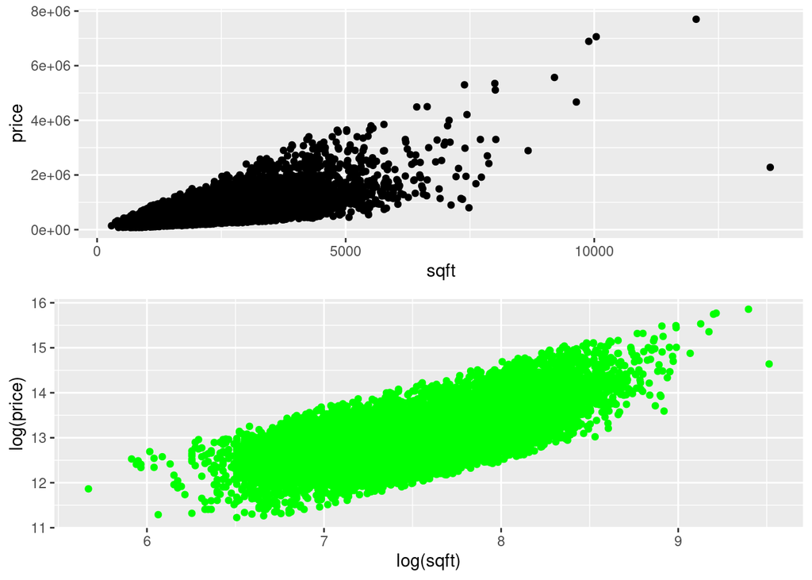

```r
plt1 = ggplot(data=housing, aes(x=sqft, y=price)) + geom_point()
plt2 = ggplot(data=housing, aes(x=log(sqft), y=log(price))) + geom_point(col='green')
grid.arrange(plt1, plt2, nrow=2, ncol=1)
```

From the summary statistics it appears that the data is right skewed as the mean is greater than the median in both price and sqft_living. We observe in the plots how applying a log transformation to both variables allows allows us to see a more linear relationship between them.

## Part B

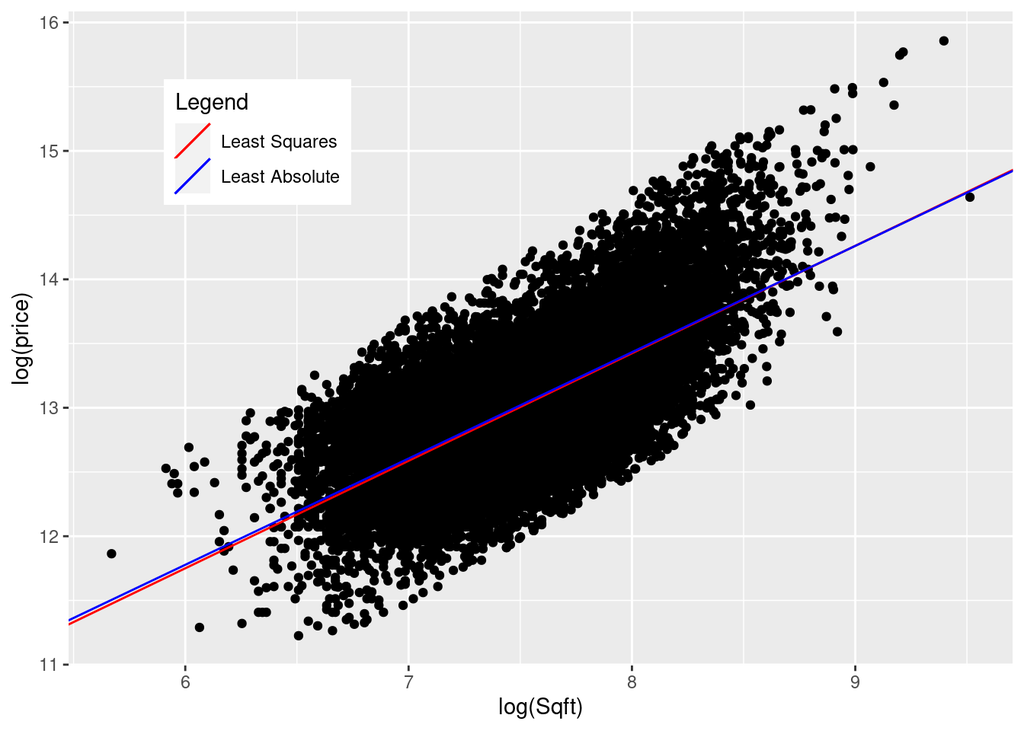

```r
housing[c('log_price', 'log_sqft')] = c(log(housing$price), log(housing$sqft))
fit.ls = lm(log_price ~ log_sqft, data=housing)
fit.lad = lad(log_price ~ log_sqft, data=housing)
colors = c('Least Squares'='red', 'Least Absolute'='blue')
ggplot(data=housing, aes(x=log_sqft, y=log_price)) + geom_point() +
  geom_abline(aes(slope=coef(fit.ls)[['log_sqft']], intercept=coef(fit.ls)[['(Intercept)']], color='Least Squares')) +
  geom_abline(aes(slope=coef(fit.lad)[['log_sqft']], intercept=coef(fit.lad)[['(Intercept)']], color='Least Absolute')) +
  labs(x = "log(Sqft)", y = "log(price)", color = "Legend") + scale_color_manual(values = colors) + theme(legend.position = c(.2,.8))
```

## Part C

```r
K = 10
housing_shuff = housing[sample(nrow(housing)),][c('log_price', 'log_sqft')]  # shuffling
bins = cut(seq(1, nrow(housing_shuff)), breaks=K, labels=FALSE)
errors_ls = numeric(length = K)
errors_lad = numeric(length = K)
for(bin_idx in 1:K){
  valIndexes = which(bins == bin_idx, arr.ind=TRUE)  # indices of 'bin_idx' bins
  val_price = housing_shuff$log_price[valIndexes]
  val_sqft = housing_shuff$log_sqft[valIndexes]
  train_price = housing_shuff$log_price[-valIndexes]
  train_sqft = housing_shuff$log_sqft[-valIndexes]

  ls = lm(train_price ~ train_sqft)
  lad = lad(train_price ~ train_sqft)

  ls_val_predictions = predict(ls, newdata=data.frame(train_sqft=val_sqft))
  lad_val_predictions = predict(lad, newdata=data.frame(train_sqft=val_sqft))

  interior_diffs_ls = (val_price - ls_val_predictions)^2
  interior_diffs_lad = (val_price - lad_val_predictions)^2

  errors_ls[bin_idx] = mean(interior_diffs_ls)
  errors_lad[bin_idx] = mean(interior_diffs_lad)
}
ls_cv_error = mean(errors_ls)
ls_cv_error
```

```
[1] 0.1511235
```

```r
lad_cv_error = mean(errors_lad)
lad_cv_error
```

```
[1] 0.1513107
```

```r
diff(c(ls_cv_error, lad_cv_error))
```

```
[1] 0.0001872171
```

## Part D

```r
housing['sqft_lot'] = king_county_house_sales["sqft_lot"]
summary(housing$price)
```

```
   Min. 1st Qu.  Median    Mean 3rd Qu.    Max.
  75000  321950  450000  540182  645000 7700000
```

```r
summary(housing$sqft_lot)
```

```
   Min. 1st Qu.  Median    Mean 3rd Qu.    Max.
    520    5040    7618   15107   10688 1651359
```

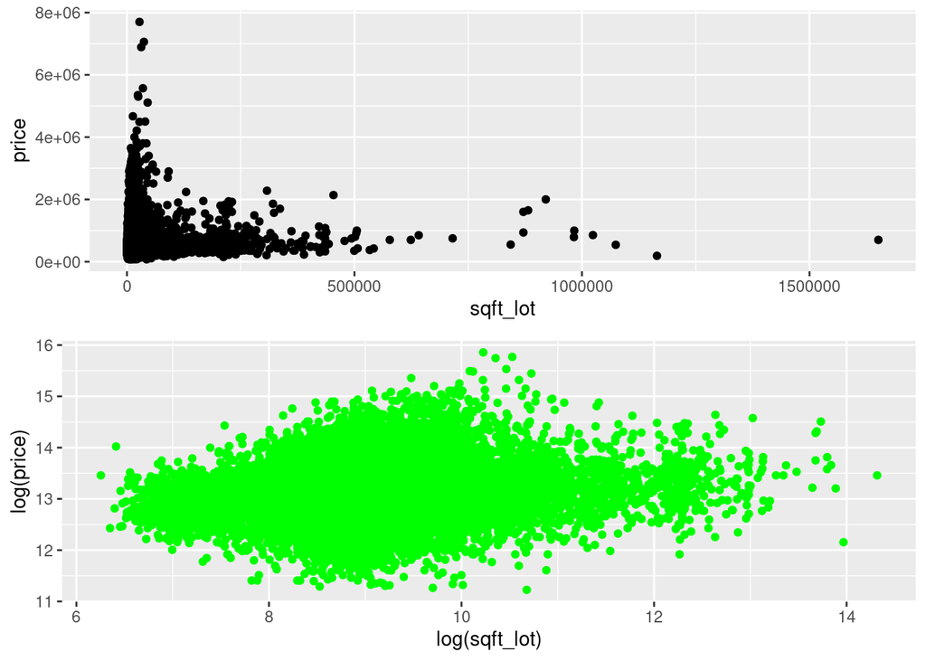

```r
plt1 = ggplot(data=housing, aes(x=sqft_lot, y=price)) + geom_point()
plt2 = ggplot(data=housing, aes(x=log(sqft_lot), y=log(price))) + geom_point(col='green')
grid.arrange(plt1, plt2, nrow=2, ncol=1)
```

We again see from the summary statistics that the data is right skewed as the mean is greater than the median in both price and sqft_lot. From the plots we see how applying a log transformation to both variables gives us a clearer regression line just as in Part A with sqft, however the relationship between the size of the lot and the price does not appear as strong as that of the house size and price.

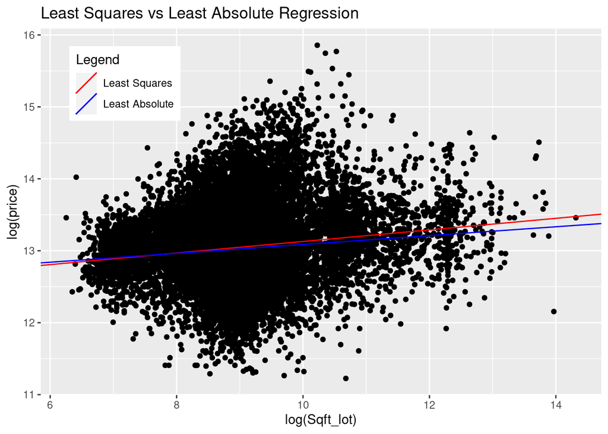

```r
housing['log_sqft_lot'] = log(housing['sqft_lot'])
fit2.ls = lm(log_price ~ log_sqft_lot, data=housing)
fit2.lad = lad(log_price ~ log_sqft_lot, data=housing)
colors = c('Least Squares'='red', 'Least Absolute'='blue')
ggplot(data=housing, aes(x=log_sqft_lot, y=log_price), ) + geom_point() + labs(title="Least Squares vs Least Absolute Regression") +
  geom_abline(aes(slope=coef(fit2.ls)[['log_sqft_lot']], intercept=coef(fit2.ls)[['(Intercept)']], color='Least Squares')) +
  geom_abline(aes(slope=coef(fit2.lad)[['log_sqft_lot']], intercept=coef(fit2.lad)[['(Intercept)']], color='Least Absolute')) +
  labs(x = "log(Sqft_lot)", y = "log(price)", color = "Legend") + scale_color_manual(values = colors) + theme(legend.position = c(.15,.85))
```

## Part E

```
Call:
lm(formula = log_price ~ log_sqft, data = housing)

Residuals:
     Min       1Q   Median       3Q      Max
-1.10504 -0.29311  0.01249  0.25694  1.32930

Coefficients:
            Estimate Std. Error t value Pr(>|t|)
(Intercept) 6.728218   0.047074   142.9   <2e-16 ***
log_sqft    0.837005   0.006225   134.5   <2e-16 ***
---
Signif. codes:  0 '***' 0.001 '**' 0.01 '*' 0.05 '.' 0.1 ' ' 1

Residual standard error: 0.3887 on 21611 degrees of freedom
Multiple R-squared:  0.4555,    Adjusted R-squared:  0.4555
F-statistic: 1.808e+04 on 1 and 21611 DF,  p-value: < 2.2e-16
```

```
Call:
lm(formula = log_price ~ log_sqft_lot, data = housing)

Residuals:
     Min       1Q   Median       3Q      Max
-1.95836 -0.36339 -0.02174  0.33035  2.70948

Coefficients:
              Estimate Std. Error t value Pr(>|t|)
(Intercept)  12.324967   0.035538  346.81   <2e-16 ***
log_sqft_lot  0.080414   0.003933   20.45   <2e-16 ***
---
Signif. codes:  0 '***' 0.001 '**' 0.01 '*' 0.05 '.' 0.1 ' ' 1

Residual standard error: 0.5218 on 21611 degrees of freedom
Multiple R-squared:  0.01897,   Adjusted R-squared:  0.01893
F-statistic:   418 on 1 and 21611 DF,  p-value: < 2.2e-16
```

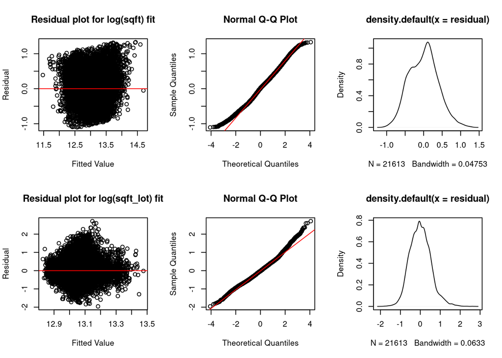

```r
par(mfrow=c(2,3))
fits = list(fit.ls, fit2.ls)
regress = c('log(sqft)', 'log(sqft_lot)')
for(i in 1:2){
  print(summary(fits[[i]]))
  residual = resid(fits[[i]])
  plot(fitted(fits[[i]]), residual, xlab='Fitted Value', ylab='Residual', main=paste('Residual plot for', regress[i], 'fit'))
  abline(0, 0, col='red')
  qqnorm(residual)
  qqline(residual, col='red')
  plot(density(residual))
}
```

From the plots we note the more favorable Residual value spread of the sqft model ‘fit.ls’ vs the sqft_lot model ’fit2.ls. Residuals seem to follow a normal distribution more closely as well according to the QQ plot. These plots lead me to believe my regression assumptions are met. The sqft also has a substantially greater R-squared value at 0.4555 vs 0.01897 for the sqft_lot model. This leads me to believe that this first model fits the data better and thus the sqft variable is the better predictor.

# Problem 2

## Part A

```r
piecewise.constant = function(x, y, M=10, x.points=seq(from=min(x), to=max(x), length.out=100)){
  bins = cut(x, breaks=M, labels=F)
  Bs = numeric(length=M) #  b_hats
  for(k in 1:M){
    kth_bin_indices = which(bins == k, arr.ind=T)
    y_vals = y[kth_bin_indices]
    Bs[k] = mean(y_vals)
  }
  x_predictions = numeric(length=length(x.points))
  bin_levels = levels(cut(x, breaks=M))
  bin_cutoffs = c(0, sapply(str_extract_all(bin_levels, "-?[0-9.]+"), function(x) max(as.numeric(x))))
  bin_indices = cut(x.points, breaks=bin_cutoffs, include.lowest=T, right=F, labels=F)
  for(i in 1:length(x.points)){
    x_predictions[i] = Bs[bin_indices[i]]
  }
  return(x_predictions)
}
```

## Part B

Simulated data

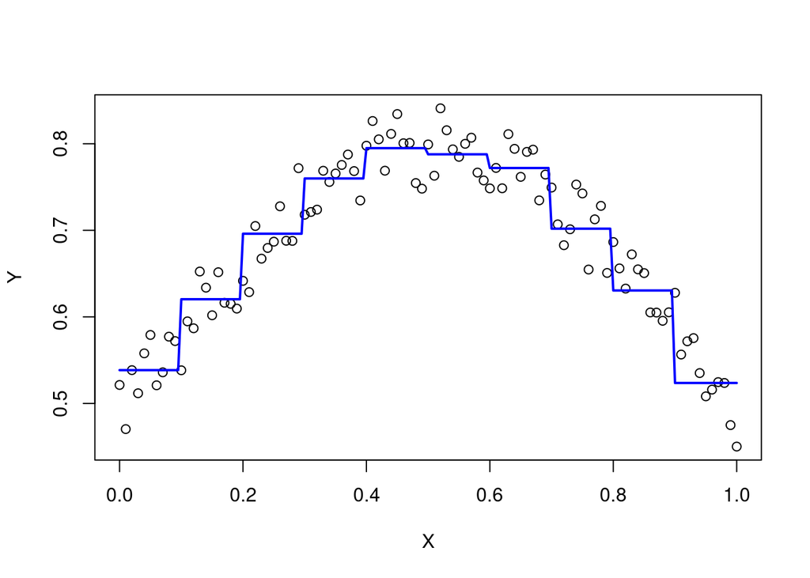

```r
X = seq(0, 1, by=.01)
Y = dnorm(X, mean=.5, sd=.5) + runif(n=length(X), min=-.05, max=.05)
plot(X, Y, xlim=c(0, 1))
predictions = piecewise.constant(X, Y, M=10, x.points=seq(0, 1, .005))
lines(x=seq(0, 1, .005), y=predictions, type="l", lwd=2, col="blue")
```

real data from https://machinelearningmastery.com/time-series-datasets-for-machine-learning/ called “Daily Female Births Dataset”

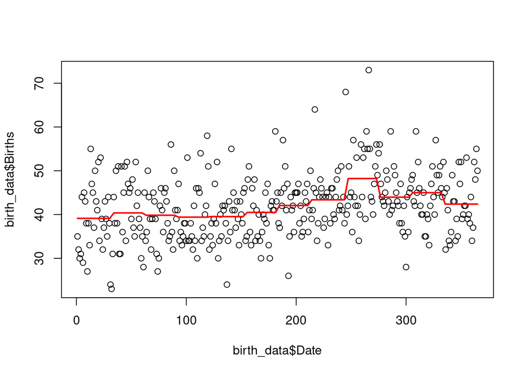

```r
birth_data = read.csv("daily-total-female-births.csv")
birth_data$Date = seq(1, length(birth_data$Date))
plot(birth_data$Date, birth_data$Births)
predictions = piecewise.constant(birth_data$Date, birth_data$Births, M = 12)
lines(x = seq(from=min(birth_data$Date), to=max(birth_data$Date), length.out=100),
      y = predictions, type = "l", lwd = 2, col = "red")
```

## Part C

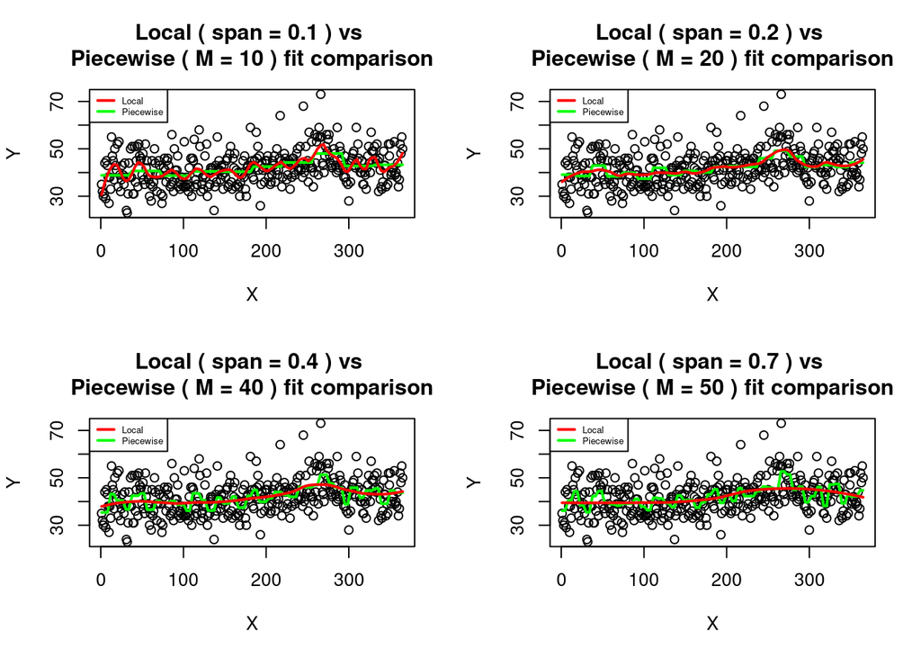

```r
par(mfrow = c(2, 2))
X = birth_data$Date
Y = birth_data$Births
x.points=seq(from=min(X), to=max(X), length.out=100)
spans = c(.1,.2,.4,.7)
Ms = c(10, 20, 40, 50)

for(i in 1:length(spans)){
  plot(X, Y, xlim=c(min(X), max(X)), main=paste('Local ( span =', spans[i], ') vs \nPiecewise ( M =', Ms[i], ') fit comparison'))
  predictions_piece = piecewise.constant(X, Y, M=Ms[i])
  lines(x.points, predictions_piece, type='l', lwd=2, col='green')
  fit_loess = loess(Y ~ X, span=spans[i])
  predictions_loess = predict(fit_loess, data.frame(X=x.points))
  lines(x.points, predictions_loess, type='l', lwd=2, col='red')
  legend('topleft', c('Local', 'Piecewise'), col=c('red', 'green'), lwd=2, lty=c(1,1), cex=0.5)
}
```

From the various plots we see pretty clearly the significance of the span and M parameters in LOESS and in piecewise respectively. With the increases in M, we increase the number of bins we use and so our fit more closely follows the data. The increase in span, and thus the increase in the amount of data being used for averaging, smooths our curve to a greater extent as it tries to account for the wider data spread. A low span and a high M give us very similar looking graphs.